# Aguas Venenosas

Daniel Salgado

26/2/2017

Desafío Aguas Venenosas Los aldeanos de la isla en la que te encuentras son víctimas de conflictos entre tribus. El método más usado para resolver conflictos ha sido el envenenamiento de aguas enemigas.

Una de las tribus está diseñando un detector de veneno. Ellos lograron identificar las 10 características mínimas y requeridas que hacen de una sustancia una sustancia venenosa para su especie (*veneno.csv*). Tu has recibido un dataset (*sustancias_diversas.csv*) de 500 sustancias diversas con las 10 características, estas sustancias fueron encontradas en distintos lagos cada una. La idea es clausurar lagos infectados. La tropa que cerrará los lagos infectados tiene sólo 50 miembros, tu debes entregar un dataset con las primeros 50 lagos que cerrará cada miembro de la tropa.

*NB: Tienes una restricción, sólo puedes usar Python y siempre que sea posible la librería Pandas. Usando la librería Pandas de Python, carga tu dataset. Una vez que tengas tu dataset de las 500 sustancias, muestra (diagrama de flujo o dibujo) cómo seleccionar a los 50 prospectos. Muestra cómo filtrarías la base para obtener 50 sustancias. Implementa tu proceso de selección en Pandas mostrando los comandos que usas. Guarda los 50 sustancias en un archivo nombrado* urgente_orden_de_cierre.csv* (Opcional) Si crees que es necesario ordenarlas en algún orden específico, indícalo.

# Opción usando R

Carguemos los datos.

```r
v <- read.csv("data_frames/Copia de veneno.csv")
s <- read.csv("data_frames/Copia de sustancias_diversas.csv")
```

Los datos del veneno tienen 11 variables, la primera es la que indica que dicha sustancia es el veneno, las siguientes estan nombradas como v1, v2, …, v10.

En el data frame de sustancias diversas, la primer columna es un numero entero unico, utilizado para identificar a cada una de las sustancias.

Tampoco tenemos información de las escalas utilizadas en cada variable, no sabemos si una diferencia de 10 en la variable *X1* es comparable con una diferencia también de 10 en *X2*. Normalizaremos las variables antes de trabajar con ellas.

```r
s[,2:11] <- scale(s[,2:11])
v[,2:11] <- scale(s[,2:11])
```

Veamos que nuestras variables ahora tienen media 0 y varianza 1

```r
media <- colMeans(s[,2:11])
varianza <- apply(s[,2:11], 2, sd)
print(paste("media = ", media, "; varianza = ", varianza))
```

```
##  [1] "media =  9.36389854544473e-16 ; varianza =  1"
##  [2] "media =  3.79678059825306e-16 ; varianza =  1"
##  [3] "media =  -1.23161745559097e-15 ; varianza =  1"
##  [4] "media =  -1.69758304635614e-16 ; varianza =  1"
##  [5] "media =  9.11545144921533e-16 ; varianza =  1"
##  [6] "media =  -3.93386712094212e-16 ; varianza =  1"
##  [7] "media =  -5.94177484991576e-16 ; varianza =  1"
##  [8] "media =  9.79598346884103e-17 ; varianza =  1"
##  [9] "media =  -2.52985132842554e-16 ; varianza =  1"
## [10] "media =  1.97064586870965e-16 ; varianza =  1"
```

Creemos una nueva columna en nuestro arreglo de sustancias diversas en donde calculemos la distancia entre el veneno y cada sustancia.

Como solo tenemos los datos de un veneno, la opcion más directa es calcular el promedio de las distancias.

```r
s$distancia <- rep(0, nrow(s))
get_dist <- function(sustancia, veneno){
  s <- sustancia
  temp <- rep(0, 10)
  for(i in 2:11){
    temp[i] <- mean(abs(s[1, i] - veneno[1, i]))
  }
  mean(temp)
}
for(i in 1:nrow(s)){
  s[i, "distancia"] <- get_dist(s[i, ], v)
}
```

Otro criterio para determinar la distancia entre una sustancia y el veneno es MSS, el promedio de las diferencias cuadradas.

```r
s$mss <- rep(0, nrow(s))
get_mss <- function(sustancia, veneno){
  s <- sustancia
  temp <- rep(0, 10)
  for(i in 2:11){
    temp[i] <- mean((s[1, i] - veneno[1, i])^2)
  }
  mean(temp)
}
for(i in 1:nrow(s)){
  s[i, "mss"] <- get_mss(s[i, ], v)
}
```

Comparemos las dos medias de distancia.

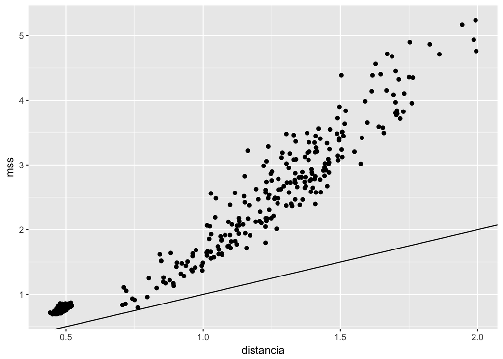

```r
ggplot(s, aes(distancia, mss)) + geom_point() +
  geom_abline(slope = 1)
```

Comparemos los criterios.

```r
sustancias_d <- head(s[ order(s$distancia), "X"], 69)
sustancias_mss <- head(s[ order(s$mss), "X"], 69)
sum(sustancias_mss %in% sustancias_d)
```

```
## [1] 50
```

```r
sum(sustancias_d %in% sustancias_mss)
```

```
## [1] 50
```

Guardemos los resultados en un .csv

```r
sustancias_peligrosas <- sustancias_d[sustancias_d %in% sustancias_mss]
s <- read.csv("data_frames/Copia de sustancias_diversas.csv")
urgente_orden_de_cierre <-  s[s$X %in% sustancias_peligrosas , 1:11]
write.csv(urgente_orden_de_cierre, "results/urgente_orden_de_cierre.csv", row.names = FALSE)
```